# GIS610: Introduction to R in GIS

### Lists

In some case a “container” needs to hold arbitrary objects that can be either the same kind of varying ones. The same goes for objects with either the same or different length. In `R`, `list` can accommodate for all of the above, as well as storing `data.frames` inside it along with simple `vectors`.

```r
list(1,2,3)
```

```
## [[1]]
## [1] 1
##
## [[2]]
## [1] 2
##
## [[3]]
## [1] 3
```

```r
#single element with 3 numbers
list(c(1,2,3))
```

```
## [[1]]
## [1] 1 2 3
```

```r
#mix of vectors and data.frame
list(DF, 1:10)
```

```
## [[1]]
##       First Second  Third
## One       1   TRUE   Mark
## Two       2   TRUE    Jim
## Three     3   TRUE  Laura
## Four      4   TRUE Jessie
## Five      5   TRUE  Frank
##
## [[2]]
##  [1]  1  2  3  4  5  6  7  8  9 10
```

```r
#names of a list
lst <- list(DF, 1:10)
names(lst)
```

[output not shown]

```r
names(lst) <- c("data.frame", "vector")
lst
```

```
## $data.frame
##       First Second  Third
## One       1   TRUE   Mark
## Two       2   TRUE    Jim
## Three     3   TRUE  Laura
## Four      4   TRUE Jessie
## Five      5   TRUE  Frank
##
## $vector
##  [1]  1  2  3  4  5  6  7  8  9 10
```

```r
#access list elements with double square brackets
lst[[1]]
```

```
##       First Second  Third
## One       1   TRUE   Mark
## Two       2   TRUE    Jim
## Three     3   TRUE  Laura
## Four      4   TRUE Jessie
## Five      5   TRUE  Frank
```

```r
#OR using name
lst[["vector"]]
```

```
##  [1]  1  2  3  4  5  6  7  8  9 10
```

```r
#select a variable inside the data frame
lst[["data.frame"]]$Second
```

```
## [1] TRUE TRUE TRUE TRUE TRUE
```

```r
#check its length
length(lst)
```

```
## [1] 2
```

```r
#add element to the list
lst[[3]] <- c("Hello", "world")
```

### Arrays

In `R`, `arrays` are used as multidimensional `vectors`. Everything inside it MUST be of the same type. Elements inside an `array` are accessed using square brackets. An `array` is defined by three indices: one for the row, the second for the column, and the following ones for outer dimension(s). The main difference between `matrices` and `arrays` in `R` is that the latter can have an arbitrary number of outer dimensions.

```r
myArray <- array(1:12, dim = c(2,3,2))
myArray
```

```
## , , 1
##
##      [,1] [,2] [,3]
## [1,]    1    3    5
## [2,]    2    4    6
##
## , , 2
##
##      [,1] [,2] [,3]
## [1,]    7    9   11
## [2,]    8   10   12
```

```r
#subset dimension of interest
myArray[1, ,1]
```

```
## [1] 1 3 5
```

# Reading Data in `R`: tables and spatial data

The most common way to read data into `R` is from CSV (Comma Separated Values) files. There are many other options, such as reading data from a database (e.g. MySQL, MS Access, etc.) or from other software output (e.g. SAS, SPSS, etc.) and many more. We will leave the exploration of all the above up to you. Our main focus will quickly shift to the two main GIS spatial data types: vectors and rasters.

### Reading CSV Files

The most common way to read csv files is using the `read.table` or `read.csv` commands. By default, csv files are read in as `data.frames`. Reading Excel spreadsheets in `R` is not that simple. It would be preferrable to first conver Excel data into csv files before loading data into `R`. However, a number of packages exist to tackle this type of data. The most common being `gdata`, `XLConnect`, `xlsReadWrite`.

```r
myTable <- read.table("./data/plots_umca_infection.csv", stringsAsFactors = FALSE, header=T, sep=',')
#using read.csv() you don't have to specify the 'sep' argument.
myTableCSV <- read.csv("./data/plots_umca_infection.csv", stringsAsFactors = FALSE, header=T)
class(myTableCSV)
```

```
## [1] "data.frame"
```

```r
head(myTableCSV)
```

```
##   X  plot year uninfected_bay_ct infected_bay_ct tot_bay ct_bay_NA
## 1 1 ANN01 2004                 8              15      23         0
## 2 2 ANN01 2005                 6              17      23         0
## 3 3 ANN01 2006                 0              25      25         0
## 4 4 ANN01 2007                 0              23      23         0
## 5 5 ANN01 2008                 0              24      24         0
## 6 6 ANN01 2009                 0              23      23         0
##   infected
## 1        1
## 2        1
## 3        1
## 4        1
## 5        1
## 6        1
```

```r
str(myTableCSV)
```

```
## 'data.frame':    1795 obs. of  8 variables:
##  $ X                : int  1 2 3 4 5 6 7 8 9 10 ...
##  $ plot             : chr  "ANN01" "ANN01" "ANN01" "ANN01" ...
##  $ year             : int  2004 2005 2006 2007 2008 2009 2010 2011 2012 2014 ...
##  $ uninfected_bay_ct: int  8 6 0 0 0 0 1 0 0 1 ...
##  $ infected_bay_ct  : int  15 17 25 23 24 23 23 24 26 23 ...
##  $ tot_bay          : int  23 23 25 23 24 23 24 24 26 24 ...
##  $ ct_bay_NA        : int  0 0 0 0 0 0 0 0 0 0 ...
##  $ infected         : int  1 1 1 1 1 1 1 1 1 1 ...
```

### Importing and Exporting Vector GIS Data in `R`

**Credits for this section go to Jillian Deines, Michigan State University and Whalen Dillon, North Carolina State University**

Now let’s read in shapefiles. Two primary functions exist to read in .shp files:

- `readShapeSpatial` in package `maptools` doesn’t read projection information; need to set manually
- `readOGR` in package ‘rgdal’ reads projection information, so **we’ll use this exclusively**. More information on manipulating projections in `R` will follow.

Here, we import a polygon boundary for the Colorado Plateau (CP) that has an Albers Equal Area projection, “COP_boundpoly_aea.shp” from the ‘data’ course subfolder.

```r
# load shapefile by specifying folder name (dsn), and layer name (no extension!)
cp.poly <- readOGR(dsn = 'data',             # subfolder name
                   layer = 'COP_boundpoly_aea')   # file name without extension
```

```
## with 1 features and 1 fields
## Feature type: wkbPolygon with 2 dimensions
```

#### Examine loaded shapefile

Let’s now take a look at what we loaded and make a simple plot of it

```r
# View description. Note the coordinate bounding box and projection info
summary(cp.poly)
```

```
## Object of class SpatialPolygonsDataFrame
## Coordinates:
##        min       max
## x -1540636 -959647.5
## y  1521625 2076338.7
## Is projected: TRUE
## proj4string :
## [+proj=aea +lat_1=29.5 +lat_2=45.5 +lat_0=23 +lon_0=-96 +x_0=0
## +y_0=0 +datum=NAD83 +units=m +no_defs +ellps=GRS80 +towgs84=0,0,0]
## Data attributes:
##    Min. 1st Qu.  Median    Mean 3rd Qu.    Max.
##       0       0       0       0       0       0
```

```r
# just look at projection
proj4string(cp.poly)
```

```
## [1] "+proj=aea +lat_1=29.5 +lat_2=45.5 +lat_0=23 +lon_0=-96 +x_0=0 +y_0=0 +datum=NAD83 +units=m +no_defs +ellps=GRS80 +towgs84=0,0,0"
```

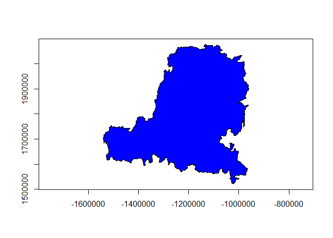

```r
# make a simple plot
plot(cp.poly, axes=T, col='blue', main = "CO Plateau")
```

#### Using readShapeSpatial in package `maptools`

You may find another common way to load shapefiles. Here we use the `readShapeSpatial` function in the package `maptools`. *Remember:* this function does NOT automatically load projection information:

```r
# load shapefile by specifying file name with extension
cp.poly2 <- readShapeSpatial('data/COP_boundpoly_aea.shp')

# look at the projection information: none
summary(cp.poly2)
```

```
## Object of class SpatialPolygonsDataFrame
## Coordinates:
##        min       max
## x -1540636 -959647.5
## y  1521625 2076338.7
## Is projected: NA
## proj4string : [NA]
## Data attributes:
##    Min. 1st Qu.  Median    Mean 3rd Qu.    Max.
##       0       0       0       0       0       0
```

You need to know your projection and define it manually by telling `R` what projection your file is in. `R` uses PROJ.4 projection definitions: find more info online at http://spatialreference.org. Right now, let’s assume I know the proj4 information. **Note that proj4strings are sensitive to spacing and can have no hard returns/line breaks**. I would recommend always trying to use `rgdal` and its `readOGR` function.

```r
# define the AEA projection information
aea.proj <- "+proj=aea +lat_1=29.5 +lat_2=45.5 +lat_0=23 +lon_0=-96 +x_0=0 +y_0=0 +datum=NAD83 +units=m +no_defs +ellps=GRS80 +towgs84=0,0,0"
# set projection of object
proj4string(cp.poly2) <- CRS(aea.proj)
# look at projection info
summary(cp.poly2)
```

```
## Object of class SpatialPolygonsDataFrame
## Coordinates:
##        min       max
## x -1540636 -959647.5
## y  1521625 2076338.7
## Is projected: TRUE
## proj4string :
## [+proj=aea +lat_1=29.5 +lat_2=45.5 +lat_0=23 +lon_0=-96 +x_0=0
## +y_0=0 +datum=NAD83 +units=m +no_defs +ellps=GRS80 +towgs84=0,0,0]
## Data attributes:
##    Min. 1st Qu.  Median    Mean 3rd Qu.    Max.
##       0       0       0       0       0       0
```

#### Import Line and Point Shapefiles

No matter what type of vector data you are working with, all shapefiles are read in the same way we just demonstrated. Let’s now load points from the “COP_Major_Cities_pt.shp” as a demonstration. *NOTE:* the shapefile has an attribute table with 47 columns/attributes.

```r
# load shapefile by specifying folder name (dsn), and layer name (no extension!)
cities <- readOGR(dsn = 'data', layer = 'COP_Major_Cities_pt')
```

```
## with 4 features and 47 fields
## Feature type: wkbPoint with 2 dimensions
```

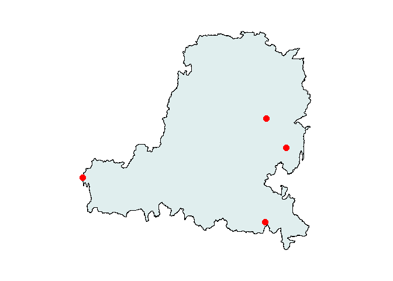

```r
# make a quick plot. note that projections need to match
par(mar=c(2,2,2,2))             # make plot margins smaller
plot(cp.poly, col='azure2')     # plot CO Plateau polygon
plot(cities, add=T,             # add city points using add=T
     col='red',                 # point color
     pch=19,                    # point type (here, solid circles)
     cex=1.5)                   # point size
```

#### Querying data of a vector (shapefile)

Let’s first read a different set of shapefiles and inspect some of their components and structures.

```r
utah.wgs84 <- readOGR(dsn = "data", layer = "utah_wgs84") # Utah border, for "pretty" plotting
```

```
## with 1 features and 59 fields
## Feature type: wkbPolygon with 2 dimensions
```

```r
deer_unit <- readOGR(dsn = "data", layer = "deerrange_UT") # Game management units
```

```
## with 29 features and 16 fields
## Feature type: wkbPolygon with 2 dimensions
```

```r
#Take a look at the game management data we loaded
summary(deer_unit)
```

```
## Object of class SpatialPolygonsDataFrame
## Coordinates:
##          min        max
## x -114.05724 -109.03485
## y   36.99921   42.00169
## Is projected: FALSE
## proj4string :
## [+proj=longlat +datum=WGS84 +no_defs +ellps=WGS84 +towgs84=0,0,0]
## Data attributes:
##    FID_ungula             UName         UNum
##  Min.   : 1.00   South Slope : 4   Min.   : 1.0
##  1st Qu.:15.00   Nine Mile   : 2   1st Qu.: 9.0
##  Median :24.00   North Slope : 2   Median :14.0
##  Mean   :24.14   Wasatch Mtns: 2   Mean   :15.1
##  3rd Qu.:39.00   West Desert : 2   3rd Qu.:20.0
##  Max.   :46.00   Book Cliffs : 1   Max.   :30.0
##                  (Other)     :16
##                       SUName       SUNum       AREA_km2
##  none                    :11   10ab   : 1   Min.   :  589.1
##  Abajo Mountains         : 1   11a    : 1   1st Qu.: 2655.1
##  Anthro                  : 1   11b    : 1   Median : 3968.5
##  Bitter Creek, south     : 1   12     : 1   Mean   : 5873.3
##  Bonanza                 : 1   13a    : 1   3rd Qu.: 6637.8
##  Currant Creek-Avintaquin: 1   14a    : 1   Max.   :23325.1
##  (Other)                 :13   (Other):23
##    SURF_AREA         DEER          DEER_SD            ELK
##  Min.   : 180   Min.   :    0   Min.   :   0.0   Min.   :    0
##  1st Qu.: 998   1st Qu.: 1530   1st Qu.: 171.0   1st Qu.:  109
##  Median :1781   Median : 8300   Median : 524.0   Median : 1020
##  Mean   :2004   Mean   : 7534   Mean   : 704.8   Mean   : 1767
##  3rd Qu.:3161   3rd Qu.:11110   3rd Qu.:1089.0   3rd Qu.: 2210
##  Max.   :4955   Max.   :21180   Max.   :1875.0   Max.   :11180
##
##      ELK_SD          FAWNS          FAWN_SD           CALVES
##  Min.   :  0.0   Min.   : 0.00   Min.   : 0.000   Min.   : 0
##  1st Qu.: 30.0   1st Qu.:54.00   1st Qu.: 5.000   1st Qu.: 0
##  Median : 91.0   Median :61.00   Median : 6.300   Median : 0
##  Mean   :167.4   Mean   :54.52   Mean   : 6.852   Mean   :15
##  3rd Qu.:226.0   3rd Qu.:66.00   3rd Qu.: 9.000   3rd Qu.:42
##  Max.   :968.0   Max.   :79.00   Max.   :14.400   Max.   :56
##
##     CALF_SD         ANNRANGE
##  Min.   :0.000   Min.   :   2.562
##  1st Qu.:0.000   1st Qu.:  41.457
##  Median :0.000   Median : 178.747
##  Mean   :1.783   Mean   : 551.329
##  3rd Qu.:3.000   3rd Qu.: 639.717
##  Max.   :8.600   Max.   :2742.693
##
```

```r
#This tells us the characteristics of the object, as well as giving a summary of the attribute data stored in the data #table. The attribute data is stored in a slot called `@data` so if we just want to look at the data stored in the #object:
summary(deer_unit@data)
```

```
##    FID_ungula             UName         UNum
##  Min.   : 1.00   South Slope : 4   Min.   : 1.0
##  1st Qu.:15.00   Nine Mile   : 2   1st Qu.: 9.0
##  Median :24.00   North Slope : 2   Median :14.0
##  Mean   :24.14   Wasatch Mtns: 2   Mean   :15.1
##  3rd Qu.:39.00   West Desert : 2   3rd Qu.:20.0
##  Max.   :46.00   Book Cliffs : 1   Max.   :30.0
##                  (Other)     :16
##                       SUName       SUNum       AREA_km2
##  none                    :11   10ab   : 1   Min.   :  589.1
##  Abajo Mountains         : 1   11a    : 1   1st Qu.: 2655.1
##  Anthro                  : 1   11b    : 1   Median : 3968.5
##  Bitter Creek, south     : 1   12     : 1   Mean   : 5873.3
##  Bonanza                 : 1   13a    : 1   3rd Qu.: 6637.8
##  Currant Creek-Avintaquin: 1   14a    : 1   Max.   :23325.1
##  (Other)                 :13   (Other):23
##    SURF_AREA         DEER          DEER_SD            ELK
##  Min.   : 180   Min.   :    0   Min.   :   0.0   Min.   :    0
##  1st Qu.: 998   1st Qu.: 1530   1st Qu.: 171.0   1st Qu.:  109
##  Median :1781   Median : 8300   Median : 524.0   Median : 1020
##  Mean   :2004   Mean   : 7534   Mean   : 704.8   Mean   : 1767
##  3rd Qu.:3161   3rd Qu.:11110   3rd Qu.:1089.0   3rd Qu.: 2210
##  Max.   :4955   Max.   :21180   Max.   :1875.0   Max.   :11180
##
##      ELK_SD          FAWNS          FAWN_SD           CALVES
##  Min.   :  0.0   Min.   : 0.00   Min.   : 0.000   Min.   : 0
##  1st Qu.: 30.0   1st Qu.:54.00   1st Qu.: 5.000   1st Qu.: 0
##  Median : 91.0   Median :61.00   Median : 6.300   Median : 0
##  Mean   :167.4   Mean   :54.52   Mean   : 6.852   Mean   :15
##  3rd Qu.:226.0   3rd Qu.:66.00   3rd Qu.: 9.000   3rd Qu.:42
##  Max.   :968.0   Max.   :79.00   Max.   :14.400   Max.   :56
##
##     CALF_SD         ANNRANGE
##  Min.   :0.000   Min.   :   2.562
##  1st Qu.:0.000   1st Qu.:  41.457
##  Median :0.000   Median : 178.747
##  Mean   :1.783   Mean   : 551.329
##  3rd Qu.:3.000   3rd Qu.: 639.717
##  Max.   :8.600   Max.   :2742.693
##
```

```r
names(deer_unit) # The attribute data names
```

```
##  [1] "FID_ungula" "UName"      "UNum"       "SUName"     "SUNum"
##  [6] "AREA_km2"   "SURF_AREA"  "DEER"       "DEER_SD"    "ELK"
## [11] "ELK_SD"     "FAWNS"      "FAWN_SD"    "CALVES"     "CALF_SD"
## [16] "ANNRANGE"
```

```r
#The `@data` slot is in fact a class `data.frame` like would be most other tables loaded into `R`, while the entire #object is a Spatial Polygons Data Frame.
class(deer_unit)
```

```
## [1] "SpatialPolygonsDataFrame"
## attr(,"package")
## [1] "sp"
```

```r
class(deer_unit@data)
```

```
## [1] "data.frame"
```

Make a basic plot with coloring based on `UName`

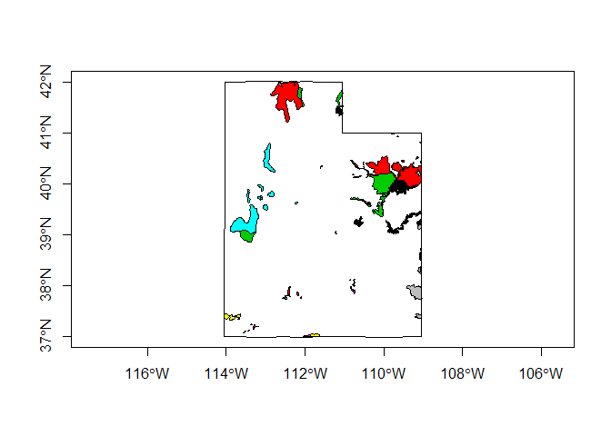

```r
plot(deer_unit,
     axes = TRUE, # adds the coordinate ranges to the axes
     col = deer_unit$UName, # colors the polygons based on UName
     main = "Utah Game Management Units" # adds main title to plot
     )
plot(utah.wgs84, add = TRUE) # Add the Utah border for reference
```

Use the `spplot` function from `sp` package to provide coloring and a legend based on the `UName` (unit name) attribute of the management units.

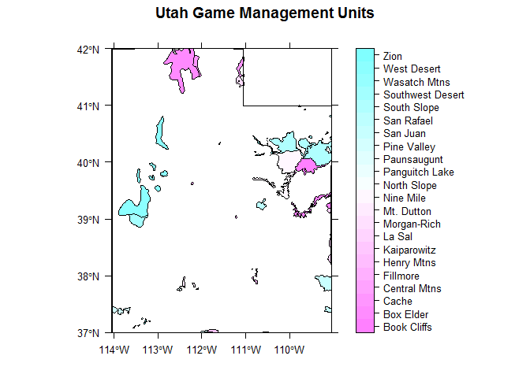

```r
spplot(deer_unit, c("UName"),
       scales = list(draw = TRUE), # this adds the coordinate values to the plot
       main = "Utah Game Management Units" # adds title to map
       # ,sp.layout = list("sp.polygons", utah.wgs84) # adds Utah border to map within call to `spplot` function
       ) +
      layer(sp.polygons(utah.wgs84)) # alternative way to add layers to map; requires `latticeExtra` package
```

Querying the data in a shapefile is much the same as querying any other data frame in `R`. For example, if you want to look at the data only for the West Desert unit.

```r
#Query data of interest
wd <- deer_unit[deer_unit$UName == "West Desert",]
summary(wd)
```

```
## Object of class SpatialPolygonsDataFrame
## Coordinates:
##          min        max
## x -113.89531 -112.75650
## y   39.02626   40.80623
## Is projected: FALSE
## proj4string :
## [+proj=longlat +datum=WGS84 +no_defs +ellps=WGS84 +towgs84=0,0,0]
## Data attributes:
##    FID_ungula             UName        UNum                    SUName
##  Min.   :18.00   West Desert :2   Min.   :19   Deep Creeks        :1
##  1st Qu.:19.25   Book Cliffs :0   1st Qu.:19   Vernon             :1
##  Median :20.50   Box Elder   :0   Median :19   Abajo Mountains    :0
##  Mean   :20.50   Cache       :0   Mean   :19   Anthro             :0
##  3rd Qu.:21.75   Central Mtns:0   3rd Qu.:19   Bitter Creek, south:0
##  Max.   :23.00   Fillmore    :0   Max.   :19   Bonanza            :0
##                  (Other)     :0                (Other)            :0
##      SUNum      AREA_km2       SURF_AREA         DEER         DEER_SD
##  19a    :1   Min.   : 3940   Min.   :1223   Min.   :8300   Min.   :524
##  19b    :1   1st Qu.: 7896   1st Qu.:1298   1st Qu.:8300   1st Qu.:524
##  10ab   :0   Median :11851   Median :1373   Median :8300   Median :524
##  11a    :0   Mean   :11851   Mean   :1373   Mean   :8300   Mean   :524
##  11b    :0   3rd Qu.:15807   3rd Qu.:1448   3rd Qu.:8300   3rd Qu.:524
##  12     :0   Max.   :19762   Max.   :1523   Max.   :8300   Max.   :524
##  (Other):0
##       ELK             ELK_SD         FAWNS         FAWN_SD         CALVES
##  Min.   :  0.00   Min.   : 0.0   Min.   :64.0   Min.   : 8.1   Min.   :0
##  1st Qu.: 27.25   1st Qu.:11.5   1st Qu.:65.5   1st Qu.: 9.3   1st Qu.:0
##  Median : 54.50   Median :23.0   Median :67.0   Median :10.5   Median :0
##  Mean   : 54.50   Mean   :23.0   Mean   :67.0   Mean   :10.5   Mean   :0
##  3rd Qu.: 81.75   3rd Qu.:34.5   3rd Qu.:68.5   3rd Qu.:11.7   3rd Qu.:0
##  Max.   :109.00   Max.   :46.0   Max.   :70.0   Max.   :12.9   Max.   :0
##
##     CALF_SD     ANNRANGE
##  Min.   :0   Min.   : 114.8
##  1st Qu.:0   1st Qu.: 771.7
##  Median :0   Median :1428.7
##  Mean   :0   Mean   :1428.7
##  3rd Qu.:0   3rd Qu.:2085.7
##  Max.   :0   Max.   :2742.7
##
```

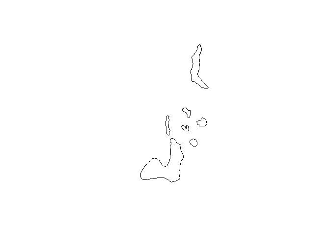

```r
plot(wd)
```

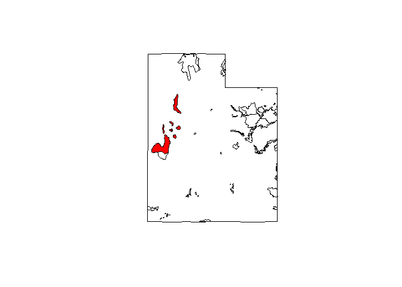

```r
plot(deer_unit, main = "West Desert Game Management Unit")
plot(utah.wgs84, add = TRUE)
plot(wd, add = TRUE, col = "red")
```

Or perhaps you just want to have a quick look at how many deer are in the Box Elder unit.

```r
deer_unit@data$DEER[deer_unit@data$UName == "Box Elder"]
```

```
## [1] 15180
```

Note that these are base `R` methods for indexing. There are also several frequently used packages that have been built to help with manipulation of data as needs become more complex, e.g. `plyr`, `dplyr`, `data.table` as three well known packages.

#### Convert Latitude/Longitude Spreadsheet Data to A Point Shapefile

If you have a spreadsheet of latitude and longitude data points, you can convert that to a spatialPointsDataFrame (spdf) in `R` and then write out a shapefile for future use. Here we’ll use coordinate data that is in .csv format, but you could also use .xls(x) provided you use the appropriate R package to load Excel files (I’d recommend `readxl`). Generally, .csv or .txt files are faster and easier to use.

Here, we’ll load lat/long presence/absence data for the species *Juniperus osteosperma* in the juos_presab.csv spreadsheet and learn how to write out shapefiles.

```r
juos <- read.csv('data/juos_presab.csv')
# look at data structure:
str(juos)
```

```
## 'data.frame':    1798 obs. of  3 variables:
##  $ juos   : int  0 0 0 1 1 1 0 1 1 0 ...
##  $ wgs84_x: num  -109 -109 -109 -109 -109 ...
##  $ wgs84_y: num  41 41 41 40.9 40.9 ...
```

```r
head(juos)
```

```
##   juos   wgs84_x  wgs84_y
## 1    0 -109.0390 40.99637
## 2    0 -109.3372 40.95580
## 3    0 -108.9809 40.95033
## 4    1 -109.4567 40.91271
## 5    1 -109.3977 40.91184
## 6    1 -109.2789 40.91011
```

```r
# convert dataframe to spdf by specifying long and lat column names
# format: ~ longitudeColumn + latitudeColumn
coordinates(juos) <- ~ wgs84_x + wgs84_y
# check out our new spdf object
summary(juos)
```

```
## Object of class SpatialPointsDataFrame
## Coordinates:
##                min        max
## wgs84_x -113.58918 -106.96000
## wgs84_y   36.34323   40.99637
## Is projected: NA
## proj4string : [NA]
## Number of points: 1798
## Data attributes:
##    Min. 1st Qu.  Median    Mean 3rd Qu.    Max.
##  0.0000  0.0000  0.0000  0.4889  1.0000  1.0000
```

Note once again that our projection is undefined. Since the .csv has no associated projection information, we need to specify it. We know that the coordinates are in a WGS84 based lat/long coordinate reference system.

```r
# create character vector defining the proj4 string for WGS84
WGS84.proj <- "+proj=longlat +datum=WGS84"
# set the proj4string
proj4string(juos) <- CRS(WGS84.proj)
# take a look
summary(juos)
```

```
## Object of class SpatialPointsDataFrame
## Coordinates:
##                min        max
## wgs84_x -113.58918 -106.96000
## wgs84_y   36.34323   40.99637
## Is projected: FALSE
## proj4string :
## [+proj=longlat +datum=WGS84 +ellps=WGS84 +towgs84=0,0,0]
## Number of points: 1798
## Data attributes:
##    Min. 1st Qu.  Median    Mean 3rd Qu.    Max.
##  0.0000  0.0000  0.0000  0.4889  1.0000  1.0000
```

Plot our new spatial points, coloring based on presence/absence attribute.

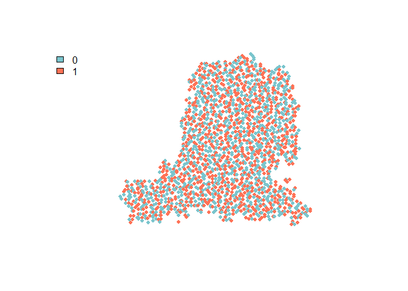

```r
# make a plot based on juos attribute column (0 or 1)
plot(juos, pch=19, cex = 0.8, col=c("cadetblue3","coral1"))
# add a simple legend
legend("topleft",                          # position in plot
       fill=c("cadetblue3","coral1"),      # match colors with plot colors
       legend = c("0","1"),                # specify legend text
       bty='n')                            # don't use a box around the legend
```

#### Write Out Shapefile

All shapefiles (points, lines, and polygons) can be written out with the `writeOGR` function in the rgdal package. Here we demonstrate with our newly created spatial point object, which we will write out to the “outData” subfolder within the module 1 data directory and call “juos_pts_wgs84.shp”.

Note that we will use the ESRI shapefile driver to create a .shp file, but the ‘driver’ argument has many options including GeoJSON, KML, etc. Typing ogrDrivers() at your command line will give a list of available drivers.

```r
# write out point shapefile.
writeOGR(obj = juos, dsn = 'data/outData', layer = 'juos_pts_wgs84',
         driver = 'ESRI Shapefile', overwrite_layer=T)
```

### Importing and Exporting Raster GIS Data in `R`

The primary package for raster work is conveniently named `raster`.

#### Load a Raster

Note that for large rasters, the raster package loads information about the data structure (rows, columns, spatial extent, filename) but processes the data in chunks from the harddrive when needed for operations. This allows it to work with objects too large to be loaded into memory but can sometimes be slow.

```r
# load raster by specifying filename with extension; extension sets format
elev1km.wgs84 <- raster("data/elev_1k_wgs.tif")
# type the name of the object to get information
elev1km.wgs84
```

```
## class       : RasterLayer
## dimensions  : 1140, 1266, 1443240  (nrow, ncol, ncell)
## resolution  : 0.008333333, 0.008333333  (x, y)
## extent      : -117.2182, -106.6682, 34.63689, 44.13689  (xmin, xmax, ymin, ymax)
## coord. ref. : +proj=longlat +ellps=WGS84 +no_defs
## data source : C:\Users\ftonini\Dropbox\GITHUB-Projects\GIS610_SpatialR\Introduction to R in GIS\data\elev_1k_wgs.tif
## names       : elev_1k_wgs
## values      : -32768, 32767  (min, max)
```

Load our polygon boundary and plot, showing base `plot` and `spplot` examples.

```r
# load our polygon boundary in WGS84 (see module 1.1 for loading vector files)
cp.latlong <- readOGR(dsn = 'data', layer = 'COP_boundpoly_wgs84')
```

```
## with 1 features and 1 fields
## Feature type: wkbPolygon with 2 dimensions
```

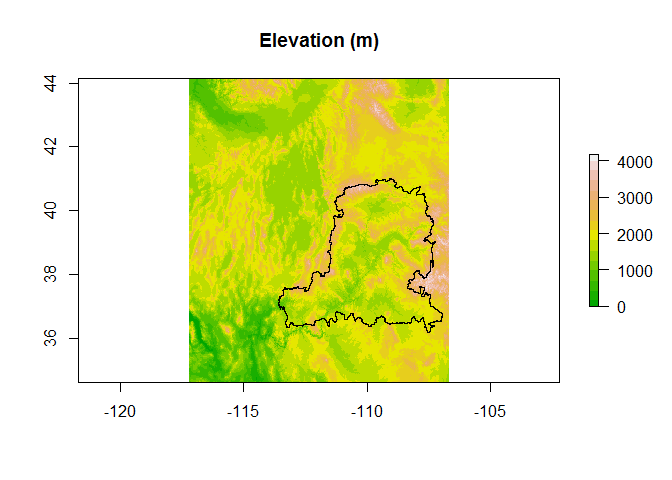

```r
# plot the raster dataset using baseplot (plot)
plot(elev1km.wgs84,
     col = terrain.colors(16),     # terrain.colors is a base color ramp
     main = "Elevation (m)")       # title of plot
# add our polygon boundary
plot(cp.latlong, add=T)
```

Note that the extent is much larger than our study region; We will cover cropping and additional extent issues later on.

#### Load Multiple Rasters (Stack)

The raster package can also load rasters of identical projection and extent directly into a raster stack, which can make operations on multiple rasters very efficient to execute. If projection and extent for files does not match, it needs to be modified prior to stacking rasters together.

To load monthly minimum temperature (tmin) files from WorldClim, we will:

- get a list of raster files within the ‘WorldClimClip’ subfolder using the `list.files` function, using regex search patterns to return files of specific extension (or name, etc.)
- load files directly into a stack using `stack`
- make a basic panel plot using `spplot`

```r
#list files in working directory subfolder with extension ".bil"
rasterFiles <- list.files(path = 'data/worldClimClip',  # specify directory
                          pattern = "*tif$",         # restrict file names using regex
                          full.names=T)              # return full file path

#load all 12 rasters at once into a stack
tmin.stack <- stack(rasterFiles)
#get information; note the "nlayers" attribute
tmin.stack
```

```
## class       : RasterStack
## dimensions  : 578, 801, 462978, 12  (nrow, ncol, ncell, nlayers)
## resolution  : 0.008333333, 0.008333333  (x, y)
## extent      : -113.6, -106.925, 36.18333, 41  (xmin, xmax, ymin, ymax)
## coord. ref. : +proj=longlat +datum=WGS84 +no_defs +ellps=WGS84 +towgs84=0,0,0
## names       : tmin01_12, tmin02_12, tmin03_12, tmin04_12, tmin05_12, tmin06_12, tmin07_12, tmin08_12, tmin09_12, tmin10_12, tmin11_12, tmin12_12
## min values  :      -221,      -207,      -191,      -140,       -84,       -44,       -12,       -18,       -44,       -80,      -144,      -196
## max values  :        -3,        21,        48,        83,       134,       182,       225,       217,       169,       101,        37,        -3
```

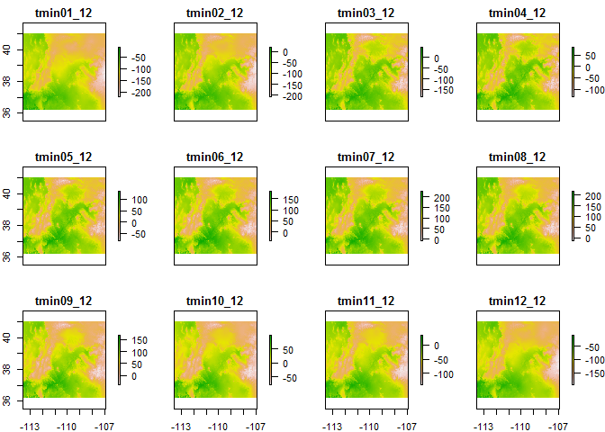

```r
#define the projection for all 12 rasters
proj4string(tmin.stack) <- CRS("+proj=longlat +datum=WGS84")
#plot rasters in the same panel
plot(tmin.stack)
```

```r
##NOT RUN:
#look at files. spplot uses R's lattice package to do automatic panelling
#May take ~1.5 minutes to make full panel of 12 plots
#spplot(tmin.stack,
#       main = "Minimum Temperature",    # plot title
#       names.attr = month.name) +       # manually set panel titles
#  layer(sp.polygons(cp.latlong))        # add boundary polygon
```

Stacks are a great way to do batch operations; for example, note that the scale on the Tmin plot is inflated by one order of magnitude. The WorldClim files are stored without decimal values to reduce files size, so to get the actual minimum temperature, we need to divide all 12 rasters by a factor of 10.

```r
#divide all 12 tmin rasters by 10
tmin.stack.corrected <- tmin.stack / 10
##NOT RUN:
#view change, note scale
#spplot(tmin.stack.corrected, main = "Minimum Temperature (C)",
#       names.attr = month.name) +
#  layer(sp.polygons(cp.latlong))
```

#### Write Out Raster

You can write out rasters in multiple formats (.tif, .img, etc) and multiple data types (binary, signed/unsigned integer, floating decimals) to manage file sizes, etc.

If the format arguments are omitted, `writeRaster` will infer the format from the filename extension, and will default to ‘FLT4S’ datatype. See ?dataType for options.

```r
# write out the raster object 'cp.ras3'
writeRaster(tmin.stack.corrected[[1]], filename = 'data/outData/cpGrid_wgs84.tif', overwrite = T)
```

#### END OF INTRODUCTION TO R IN GIS